# Projet R M1 MAS

#### 3.2 Etablir le lien entre la dansabilité des chansons en moyenne de tous les artistes de tracks, et la popularité en moyenne de l’artiste lui-même.

```r
#Faisons une régression linéaire pour voir s'il y a corrélation entre la popularité et la dansabilité des chansons.
reg_popularity<-lm(Popularity~danceability, data = tracks)
summary(reg_popularity)
```

```
##
## Call:
## lm(formula = Popularity ~ danceability, data = tracks)
##
## Residuals:
##     Min      1Q  Median      3Q     Max
## -49.133 -11.459  -0.506  11.677  54.324
##
## Coefficients:
##              Estimate Std. Error t value Pr(>|t|)
## (Intercept)   35.0014     0.4425   79.10   <2e-16 ***
## danceability  17.4995     0.7785   22.48   <2e-16 ***
## ---
## Signif. codes:  0 '***' 0.001 '**' 0.01 '*' 0.05 '.' 0.1 ' ' 1
##
## Residual standard error: 17.18 on 17566 degrees of freedom
##   (428 observations effacées parce que manquantes)
## Multiple R-squared:  0.02796,    Adjusted R-squared:  0.0279
## F-statistic: 505.3 on 1 and 17566 DF,  p-value: < 2.2e-16
```

```r
##Ici on remarque qu'il n'y a pas de corrélations entre les variables popularity et danceability car R^2 = 0.02796 < 1.

##Cela veut dire que la popularité de l'artiste  n'est pas influencée par la dansabilité de ses chansons, ainsi une chanson peut être très dansable alors que son artiste n'est pas très populaire.
```

### 4. Etablir un tableau avec toutes les chansons dans tracks qui ont le même nom qu’un album dans le Top 500 de Rolling Stones avec l’artiste, la position de l’album, la chanson associé à un album, l’année, leur popularité moyenne ainsi que la dansabilité moyenne.

```r
#Ici, nous avons les chansons de tracks qui ont le même nom qu'un album dans le Top 500 de Rolling Stones, et parmis ces chansons, nous retrouvons des doublons. En effet, il y a 75 chansons mais pour certains artistes, il y a plusieurs versions de la même chanson. Par exemple: Black Sabbath avec la chanson Paranoid ou encore Chet Faker avec la chanson Low. Donc, il faut trouver les artistes ayant plusieurs versions de leurs chansons pour qu'on puisse les trier et faire la moyenne de popularité et de dansabilité.

tracks %>%
  drop_na() %>%
  filter(Track.Name %in% top500$Album) %>%
  arrange(desc(Track.Name)) %>%
  select(Artist.Name, Track.Name,Popularity,danceability)
```

```
##                      Artist.Name          Track.Name Popularity danceability
## 1              Avenged Sevenfold  Wish You Were Here         56        0.572
## 2                        Incubus  Wish You Were Here         70        0.246
## 3                     Pink Floyd  Wish You Were Here         76        0.481
## 4                   Sparklehorse  Wish You Were Here         47        0.787
## 5                       grandson                 War         54        0.369
## 6           Cigarettes After Sex               Touch         59        0.483
## 7              Bruce Springsteen           The River         67        0.587
## 8                           EPMD   Strictly Business         48        0.712
## 9                           Sonn             Rumours         49        0.750
## 10                 Primal Scream               Rocks         60        0.619
## 11                 Primal Scream               Rocks         60        0.619
## 12 Silver Lake by Esa Holopainen        Ray of Light         38        0.462
## 13                Motâ\210šâ\210‚rhead             Ramones         44        0.387
## 14                    Freak Slug               Radio         42        0.693
```

[output cut: 61 more lines]

```r
tracks5 <- tracks %>%
           drop_na()%>%
           filter(Track.Name%in%top500$Album) %>%
           group_by(Artist.Name,Track.Name) %>% # ici on trouve la popularité moyenne, la dansabilité moyenne des artistes ayant les tracks doublons, donc il y a 62 chansons, if faut qu'on groupe_by(Artist.Name,Track.Name) car un artiste peut avoir plus d'une chanson.
           summarise(mean_popularity=mean(Popularity),
                     mean_danceability=mean(danceability)
           )
chansons_tracks_Top500 <- left_join(tracks5,top500,by=c("Track.Name"="Album")) %>% select(Artist.Name, Number, Track.Name, Year, mean_popularity, mean_danceability) %>% arrange(Number, Track.Name)
chansons_tracks_Top500
```

```
## # A tibble: 62 x 6
## # Groups:   Artist.Name [61]
##    Artist.Name      Number Track.Name   Year mean_popularity mean_danceability
##    <chr>             <int> <chr>       <int>           <dbl>             <dbl>
##  1 Dennis Lloyd         17 Nevermind    1991              40             0.601
##  2 Sonn                 26 Rumours      1977              49             0.75
##  3 bl00dwave            30 Blue         1971              33             0.626
##  4 Shadow and Light     30 Blue         1971              11             0.658
##  5 Thyla                30 Blue         1971              23             0.566
##  6 Motâˆšâˆ‚rhead       33 Ramones      1976              44             0.387
##  7 Inter Arma           76 Purple Rain  1984              33             0.438
##  8 Prince               76 Purple Rain  1984              75             0.367
##  9 Ben Platt            80 Imagine      1971              72             0.541
## 10 Josh Gray            80 Imagine      1971              46             0.639
## # ... with 52 more rows
```

```r
## On remarque par exemple que beaucoup de chansons, qui correspondent aux noms des albums du Top 500 de Rolling Stones, ont le même nom sans pour autant être du même artiste (car nous avons regroupé les doublons).
```

### 5.1 Ensuite, nous nous intéressons à l’influence mutuelle des variables, à partir desquelles nous pouvons conclure si la popularité est affectée par des facteurs importants ou non.

En parlant d’analyse de données, une méthode statistique descriptive nous permet de condenser l’information contenue dans le tableau : c’est l’analyse des corrélations entre les variables.

Donc en choisissant n’importe quelle paire de variables, on peut considérer leur corrélation. Mais, comment savoir quelles paires ont une corrélation élevée et notable et lesquelles ont une faible corrélation ? Pour cela, dans l’étape suivante, nous calculons la corrélation de toutes les paires de variables, et la représentation triangulaire nous aide à voir immédiatement les corrélations élevées car elles sont de couleur plus foncée.

```r
print(cor(tracks2[3:17])) #nous donne les valeurs plus précises si nous voulons rechercher
```

[output not shown]

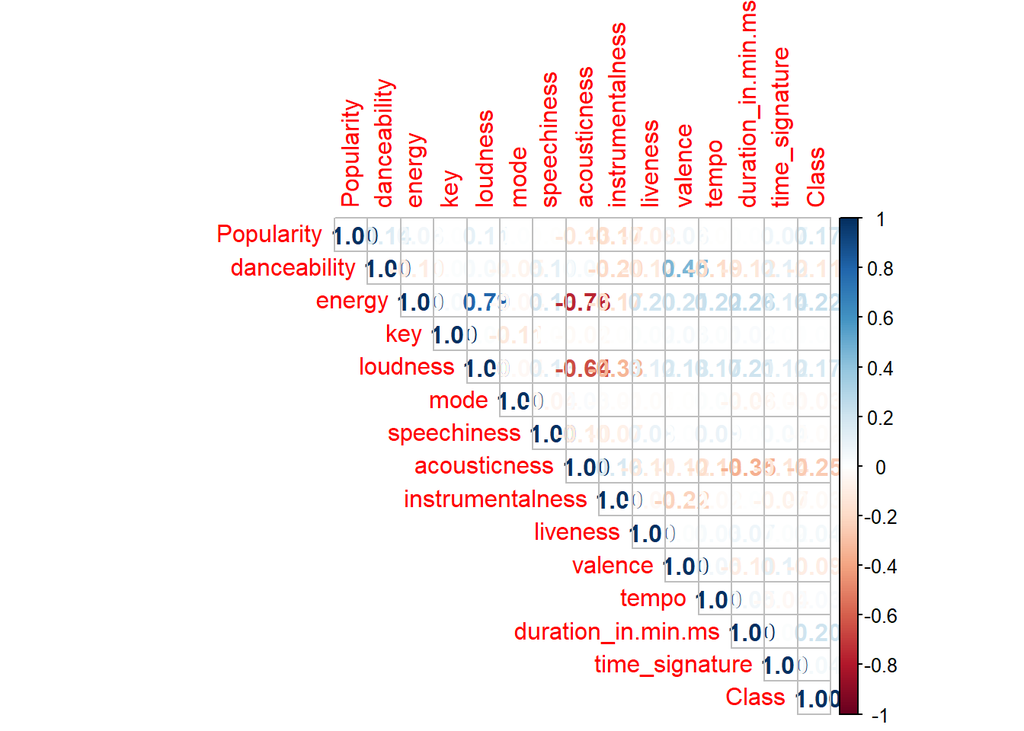

```r
corrplot(cor(tracks2[3:17]), type="upper",method="number", insig = "blank") #Les chiffres notables sont de couleur plus foncée
```

Nous voyons que les chiffres notables de couleur plus foncée sont 0.79;-0.76;-0.64 (corrélations fortes et modérées).

#### L’influence mutuelle des variables:

Nous en déduisons que ‘energy’ et ‘loudness’ sont corrélées positivement, avec un fort score de 0,79. On peut dire que les chansons qui sont rapides, fortes et bruyantes ont tendance à avoir les niveaux audio élévés, et vice versa.

Les variables ‘energy’ et ‘acousticness’ sont corrélées fortement négativement, avec un score de -0,76. On peut en déduire que, les chansons qui sont rapides, fortes et bruyantes ne sont généralement pas celles qui sont avec une acoustique élevée. Au contraire, celles qui sont plus susceptibles d’utiliser des instruments acoustiques et non électroniques, ont moins d’énergie, sont lentes et moins bruyantes.

Le troisième nombre notable dans le résultat ci-dessus est la corrélation modérée entre ‘loudness’ et ‘acousticness’, de -0.64. Les chansons avec une acoustique élevée ont tendance à avoir le niveau de décibels moins élevé, le bruit est moins fort.

(Nous pouvons tracer le cercle de corrélation par l’ACP mais cela donne le même sens, de plus, nous ne pouvons pas collecter les chiffres comme le tableau ci-dessus alors nous ne le tracons pas ici.)

### 5.2 Et maintenant, les relations avec la popularité?

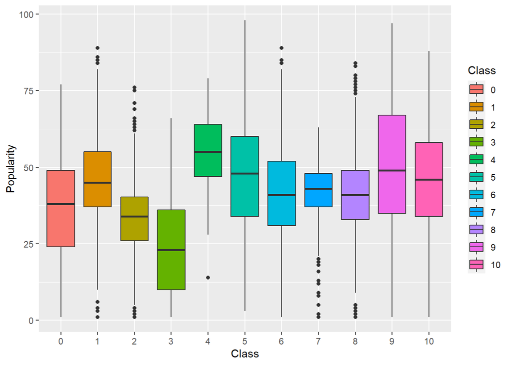

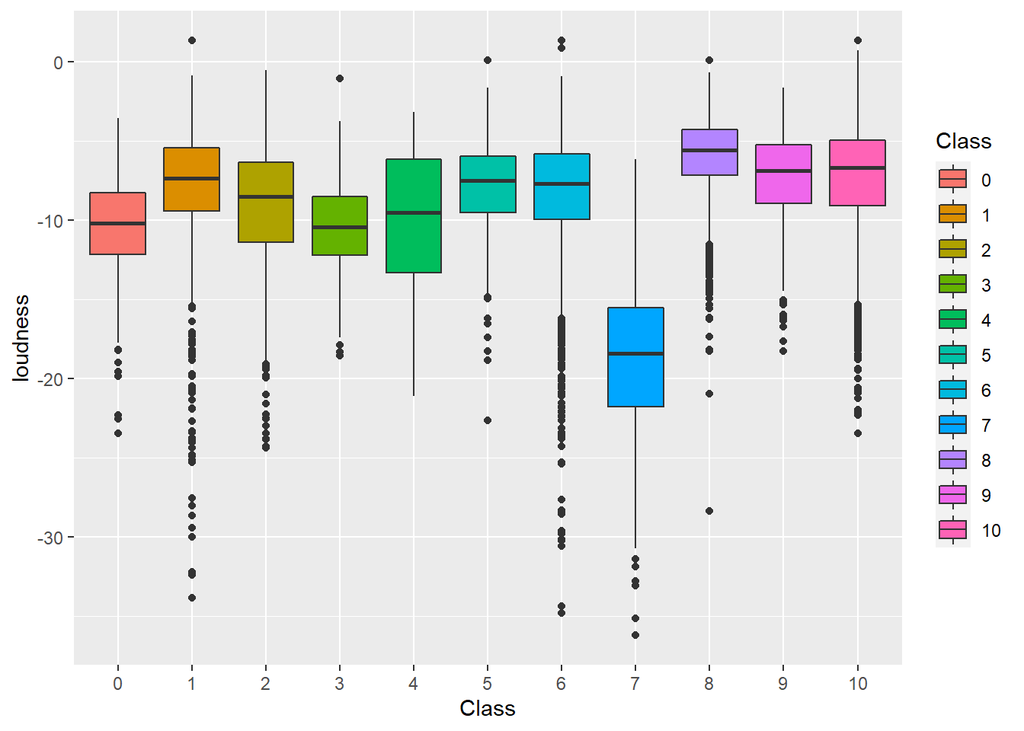

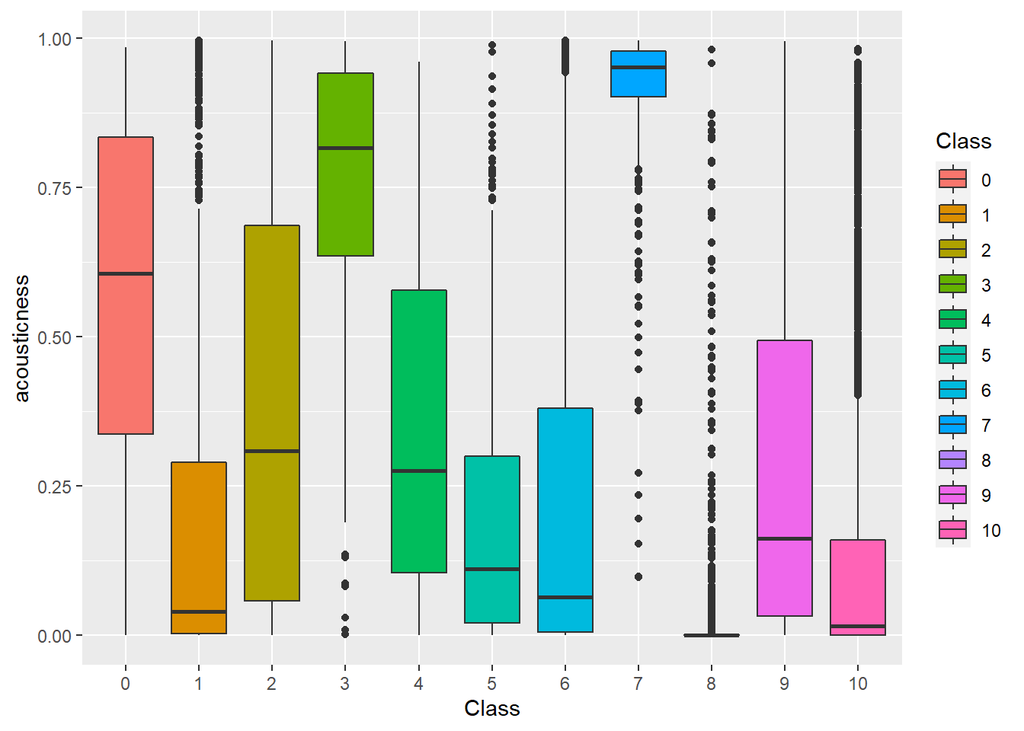

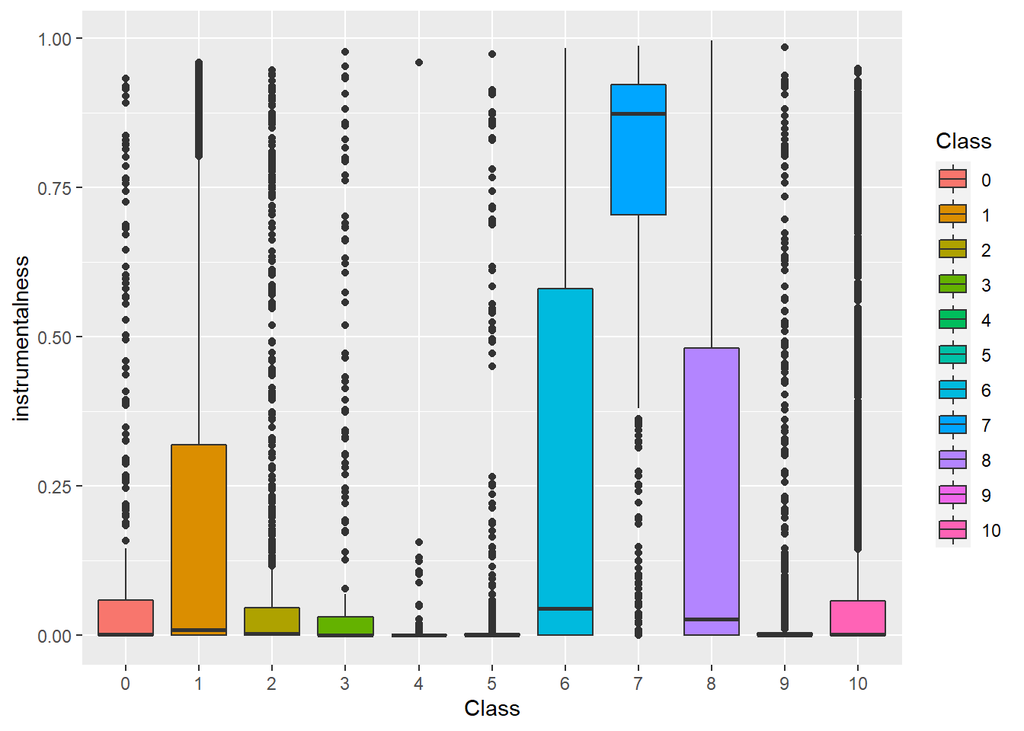

```r
tracks2$Class <- as.factor(tracks2$Class)
for (i in c(3,7,10,11)){
  print(ggplot(data=tracks2,aes(x=Class,y=tracks2[,i])) + geom_boxplot(aes(fill=Class)) + labs(y=names(tracks2[3:16])[i-2]))}
```

Choisissons les 3 corrélations les plus élevées (hors corrélations avec ‘Danceability’ car nous avons commenté par une autre méthode ces résultats au début de la partie 2):

#### ‘Popularity’ et ‘Loudness’: 0.11

Le top 5 ‘Popularity’ est de ‘class’ 1,4,5,9,10 (voir le boxplot). Quatre sur cinq d’entre eux sont dans le top 5 ayant les médianes les plus élevées de ‘Loudness’. Il y a une corrélation faible et positive de 0.11 entre ‘Popularity’ et ‘Loudness’.

#### ‘Popularity’ et ‘Acousticness’: -0.13

Il y a une corrélation négative de -0.13 entre ‘Popularity’ et ‘Acousticness’. Par conséquent, le top 5 ‘Popularity’(‘class’ 1,4,5,9,10) se trouve généralement aux valeurs ‘Acousticness’ moins élevées.

#### ‘Popularity’ et ‘Instrumentalness’: -0.17

Ici, nous avons Une autre corrélation négative de -0.17. Par conséquent, bien que la plupart soient de faibles valeurs, le top 5 ‘Popularity’(‘class’ 1,4,5,9,10) n’a pas les valeurs qui ont le niveau ‘Instrumentalness’ élevé (voir le boxplot).

#### Autre variables: très faibles corrélations (‘Speechiness -0.004, ’Valence’ 0,06, etc)

Nous avons fait les boxplots mais les phénomènes sont à peine visibles, donc ils ne sont pas aussi significatifs que les trois précédents.

#### Conclusion:

La popularité n’est influencée fortement par aucun facteur. Il y a des facteurs comme plus de ‘Loudness’, moins de ‘Instrumentalness’ (évite de contenir du contenu vocal), moins de ‘Acousticness’ (évite d’avoir de l’électronique, d’avoir de l’énergie lente) qui sont des points qui peuvent être trouvés dans les chansons populaires, mais pas forcément.